# Modelling 3 different frequency

Author

Eva, Utku, Özge

# 1 Recap: variables and transformations

**Core variables:**

- `Coord`: token frequency of the exact conjunct pair `X ve Y`.
- `rank`: ordinal rank of `Coord` (higher rank = rarer pair).
- `PMI`: pointwise mutual information, `Coord / (C1 * C2)`.
- `cPMI`: context-restricted PMI, `Coord / (C1andN * NandC2)`.
- `csumPMI`: symmetrized, context-restricted PMI using both directions and context totals.
- `rel_freq`: `Coord / sum(Coord)`.

**Modeling transforms:**

- `logCoord_z`: `scale(log(Coord + 1))`.
- `log_rank_z`: `scale(log(rank))`.
- `log_csumPMI_z`: `scale(log1p(csumPMI))`.

**Design + coding:**

| **Factor** | **Level** | **Contrast 1** | **Contrast 2** | **Contrast 3** |
| --- | --- | --- | --- | --- |
| **is_sa** | 0 (Non-suspended) | +0.5 | — | — |
|  | 1 (Suspended) | −0.5 | — | — |
| **suffix** | −cI | +0.5 | 0.0 | 0.0 |
|  | −lI | 0.0 | +0.5 | 0.0 |
|  | −lIk | 0.0 | 0.0 | +0.5 |
|  | −sIz | −0.5 | −0.5 | −0.5 |

**Empirical relationships among frequency measures (Eva checked this):**

- `Coord` is largely orthogonal to PMI-family measures (weak |r| with PMI/cPMI/csumPMI).
- `cPMI` and `csumPMI` are nearly collinear (~0.98); they capture the same construct.
- `PMI` correlates moderately with `cPMI`/`csumPMI` (~0.5).

```r
# packages
invisible(lapply(c("dplyr", "ggplot2", "tidyr", "readr", "purrr", "stringr", "knitr", "brms", "tidybayes", "loo"), library, character.only = TRUE))


# load scripts
invisible(lapply(list.files("./scripts", "\\.R$", full.names = TRUE), source))

# load data
exp <- read_csv("./data/exp_data.csv")

freq <- read_csv("../freqs_for_analysis.csv")

rank_freq <- freq %>%
  arrange(desc(Coord)) %>%
  mutate(
    rank = row_number(),
    rel_freq = Coord / sum(Coord)
  )


lex <- rank_freq %>%
  transmute(
    item,
    Coord, PMI, cPMI, csumPMI, rank, rel_freq,
    word = str_split(item, fixed(" ve "))
  ) %>%
  unnest_longer(word) %>%
  mutate(word = str_squish(word))

lex <- lex %>% mutate(word = dplyr::recode(word, "ilim" = "bilim"))

exp_joined <- exp %>% left_join(lex, by = c("conj1" = "word"))

exp_joined <- exp_joined %>%
  mutate(logCoord = log(Coord + 1)) %>%
  mutate(logCoord_z = scale(logCoord)[, 1]) %>%
  mutate(log_rank = log(rank), log_rank_z = scale(log_rank)[, 1])
```

```r
exp_joined$is_sa <- as.factor(exp_joined$is_sa)
exp_joined$rating <- factor(exp_joined$rating, ordered = TRUE)
exp_joined <- exp_joined %>%
  group_by(completionCode) %>%
  mutate(subject = paste0("S", cur_group_id())) %>%
  ungroup()
exp_joined$subject <- as.factor(exp_joined$subject)
exp_joined$itemNum <- as.factor(exp_joined$itemNum)
exp_joined$suffix <- as.factor(exp_joined$suffix)

contrasts(exp_joined$is_sa) <-  contr.sum(2)/2
contrasts(exp_joined$suffix) <- contr.sum(4)/2

my_prior <- c(
  prior(normal(0, 0.5), class = "b", coef = "is_sa1"),
  prior(exponential(1), class = "sd", group = "subject"),
  prior(exponential(1), class = "sd", group = "itemNum"),
  prior(exponential(1), class = "sd", coef = "is_sa1", group = "subject"),
  prior(lkj(2), class = "cor"),
  prior(normal(0, 5), class = "Intercept")
)
```

```r
run_model_all_suffixes <- function(
  data,
  prior,
  freq_var = "logCoord_z",
  model_path_prefix = "./models/",
  chains = 4, iter = 4000, cores = 8,
  adapt_delta = 0.95, max_treedepth = 15,
  decomp = "QR",
  backend = "cmdstanr",
  threads_per_chain = NULL,
  title_prefix = "Posterior Distributions (all suffixes)"
) {
  stopifnot(freq_var %in% names(data))
  data <- data %>%
    mutate(
      suffix  = factor(suffix),
      is_sa   = factor(is_sa)
    )

  # formula
  rhs     <- paste0("1 + is_sa * suffix * ", freq_var)
  re_subj <- paste0("(1 + is_sa * suffix * ", freq_var, " | subject)")
  re_item <- "(1 + is_sa * suffix | itemNum)"
  formula_str <- paste("rating ~", rhs, "+", re_subj, "+", re_item)

  # model itself
  brm_args <- list(
    formula = bf(as.formula(formula_str), decomp = decomp),
    data = data,
    family = cumulative(link = "logit"),
    prior = prior,
    chains = chains, iter = iter, cores = cores,
    control = list(adapt_delta = adapt_delta, max_treedepth = max_treedepth),
    file = file.path(model_path_prefix, paste0("model_all_", freq_var))
  )
  if (!is.null(backend)) brm_args$backend <- backend
  if (!is.null(threads_per_chain)) brm_args$threads <- threading(threads_per_chain)

  fit <- do.call(brm, brm_args)

  post_fixef <- fit %>%
    tidybayes::gather_draws(`b_.*`, regex = TRUE) %>%
    rename(term = .variable, estimate = .value) %>%
    select(-.chain, -.iteration, -.draw)

  # getting a summary
  posterior_summary <- post_fixef %>%
    group_by(term) %>%
    summarise(
      p_gt_0       = mean(estimate > 0),
      avg_estimate = mean(estimate),
      ci_95_low    = quantile(estimate, .025),
      ci_95_high   = quantile(estimate, .975),
      .groups = "drop"
    )

  # labelling
  pretty_term <- function(x) {
    x %>%
      str_remove("^b_") %>%
      str_replace_all(":", " × ")
  }

  posterior_summary <- posterior_summary %>%
    mutate(term_pretty = pretty_term(term)) %>%
    arrange(avg_estimate)

  post_fixef <- post_fixef %>%
    left_join(posterior_summary, by = "term") %>%
    mutate(term_pretty = factor(term_pretty, levels = posterior_summary$term_pretty))

  # plotting
  x_range <- range(post_fixef$estimate)
  buffer  <- diff(x_range) * 0.3
  max_x   <- max(post_fixef$estimate)

  p <- ggplot(post_fixef, aes(x = estimate, y = term_pretty)) +
    stat_halfeye(.width = c(.66, .95)) +
    geom_vline(xintercept = 0, linetype = "dashed") +
    geom_text(
      data = posterior_summary,
      aes(
        x = max_x + buffer * 0.1,
        y = term_pretty,
        label = paste0("P(β>0) = ", sprintf("%.2f", p_gt_0))
      ),
      hjust = 0,
      inherit.aes = FALSE
    ) +
    labs(
      x = "Effect",
      y = "Coefficient",
      title = paste0(title_prefix, " · freq var = ", freq_var)
    ) +
    theme_minimal() +
    coord_cartesian(xlim = c(x_range[1], max_x + buffer))

  # brms fixef table
  fixef_table <- as.data.frame(brms::fixef(fit, robust = FALSE, probs = c(.025, .5, .975)))
  fixef_table$term <- rownames(fixef_table)
  rownames(fixef_table) <- NULL
  fixef_table <- fixef_table %>% relocate(term)

  list(model = fit, plot = p, summary = posterior_summary, fixef = fixef_table)
}

suffix_is_sa_contrasts <- function(fit, data, freq_var = "logCoord_z", freq_at = 0) {
  stopifnot(freq_var %in% names(data))
  sf <- levels(factor(data$suffix))

  newdata <- do.call(rbind, lapply(sf, function(s) {
    rbind(
      data.frame(is_sa = factor(0, levels = levels(data$is_sa)), suffix = factor(s, levels = sf)),
      data.frame(is_sa = factor(1, levels = levels(data$is_sa)), suffix = factor(s, levels = sf))
    )
  }))
  newdata[[freq_var]] <- freq_at

  # population-level stuff
  lp <- brms::posterior_linpred(fit, newdata = newdata, re_formula = NA)

  idx0 <- seq(1, nrow(newdata), by = 2)
  idx1 <- seq(2, nrow(newdata), by = 2)

  deltas <- lp[, idx1, drop = FALSE] - lp[, idx0, drop = FALSE]
  colnames(deltas) <- sf

  summ <- lapply(sf, function(s) {
    d <- deltas[, s]
    data.frame(
      suffix     = s,
      avg        = mean(d),
      p_gt_0     = mean(d > 0),
      ci_95_low  = quantile(d, .025),
      ci_95_high = quantile(d, .975)
    )
  }) %>% bind_rows()

  list(draws = deltas, summary = summ)
}

freq_effect_by_suffix <- function(fit, data, freq_var = "logCoord_z",
                                  low = -1, high = 1, is_sa_level = 1) {
  stopifnot(freq_var %in% names(data))
  sf <- levels(factor(data$suffix))

  # two frequency values: low and high (e.g., -1 SD vs +1 SD)
  newdata <- do.call(rbind, lapply(sf, function(s) {
    rbind(
      data.frame(
        is_sa = factor(is_sa_level, levels = levels(data$is_sa)),
        suffix = factor(s, levels = sf),
        freq = low
      ),
      data.frame(
        is_sa = factor(is_sa_level, levels = levels(data$is_sa)),
        suffix = factor(s, levels = sf),
        freq = high
      )
    )
  }))

  # rename freq column to match freq_var
  names(newdata)[names(newdata) == "freq"] <- freq_var

  # population-level linear predictor
  lp <- brms::posterior_linpred(fit, newdata = newdata, re_formula = NA)

  # differences: high - low
  idx_low <- seq(1, nrow(newdata), by = 2)
  idx_high <- seq(2, nrow(newdata), by = 2)

  deltas <- lp[, idx_high, drop = FALSE] - lp[, idx_low, drop = FALSE]
  colnames(deltas) <- sf

  # summarize
  summ <- lapply(sf, function(s) {
    d <- deltas[, s]
    data.frame(
      suffix     = s,
      avg        = mean(d),
      p_gt_0     = mean(d > 0),
      ci_95_low  = quantile(d, .025),
      ci_95_high = quantile(d, .975)
    )
  }) %>% dplyr::bind_rows()

  list(draws = deltas, summary = summ)
}


item_suffix_sa_contrasts <- function(result,
                                     freq_var = "logCoord_z",
                                     freq_at = 0,
                                     prob = c(.66, .95),
                                     facet_scales = "free_y") {
  fit <- result$model
  dat <- fit$data
  stopifnot(freq_var %in% names(dat))

  items    <- levels(factor(dat$itemNum))
  suffixes <- levels(dat$suffix)
  islvls   <- levels(dat$is_sa)

  base <- expand.grid(itemNum = items, suffix = suffixes, KEEP.OUT.ATTRS = FALSE, stringsAsFactors = FALSE)
  nd0  <- transform(base, is_sa = factor(islvls[1], levels = islvls), .which = "is0")
  nd1  <- transform(base, is_sa = factor(islvls[2], levels = islvls), .which = "is1")
  newdata <- rbind(nd0, nd1)

  newdata[[freq_var]] <- freq_at

  newdata$itemNum <- factor(newdata$itemNum, levels = levels(dat$itemNum))
  newdata$suffix  <- factor(newdata$suffix,  levels = levels(dat$suffix))
  newdata$is_sa   <- factor(newdata$is_sa,   levels = levels(dat$is_sa))

  lp <- brms::posterior_linpred(
    fit,
    newdata   = newdata,
    re_formula = ~ (1 + is_sa * suffix | itemNum)
  )

  idx0 <- which(newdata$.which == "is0")
  idx1 <- which(newdata$.which == "is1")
  stopifnot(
    all(newdata$itemNum[idx0] == newdata$itemNum[idx1]),
    all(newdata$suffix[idx0]  == newdata$suffix[idx1])
  )

  deltas <- lp[, idx1, drop = FALSE] - lp[, idx0, drop = FALSE]
  keys   <- newdata[idx0, c("itemNum", "suffix")]

  lo66 <- (1 - prob[1]) / 2; hi66 <- 1 - lo66
  lo95 <- (1 - prob[2]) / 2; hi95 <- 1 - lo95

  summ <- purrr::map_dfr(seq_len(ncol(deltas)), function(j) {
    d <- deltas[, j]
    tibble::tibble(
      itemNum  = as.character(keys$itemNum[j]),
      suffix   = as.character(keys$suffix[j]),
      estimate = mean(d),
      p_gt_0   = mean(d > 0),
      low66    = stats::quantile(d, lo66),
      high66   = stats::quantile(d, hi66),
      low95    = stats::quantile(d, lo95),
      high95   = stats::quantile(d, hi95)
    )
  })

  if (requireNamespace("tidytext", quietly = TRUE)) {
    summ <- dplyr::mutate(summ, item_for_facet = tidytext::reorder_within(itemNum, estimate, suffix))
    y_aes <- ggplot2::aes(y = item_for_facet)
    y_scale <- tidytext::scale_y_reordered()
  } else {
    summ <- dplyr::mutate(summ, item_for_facet = stats::reorder(itemNum, estimate))
    y_aes <- ggplot2::aes(y = item_for_facet)
    y_scale <- NULL
  }

  p <- ggplot2::ggplot(summ, ggplot2::aes(x = estimate)) +
    ggplot2::geom_errorbarh(ggplot2::aes(xmin = low95, xmax = high95), height = 0) +
    ggplot2::geom_errorbarh(ggplot2::aes(xmin = low66, xmax = high66), height = 0, linewidth = 1.1) +
    ggplot2::geom_point(size = 1.8) +
    ggplot2::geom_vline(xintercept = 0, linetype = "dashed", color = "gray50") +
    ggplot2::facet_wrap(~ suffix, scales = facet_scales) +
    ggplot2::labs(
      x = "Δ SA (is_sa=1 − is_sa=0) at reference frequency (log-odds)",
      y = "Item",
      title = sprintf("Item × suffix SA contrasts at %s = %s", freq_var, as.character(freq_at))
    ) +
    ggplot2::theme_minimal(base_size = 12) +
    y_aes +
    (if (is.null(y_scale)) ggplot2::theme() else y_scale)

  list(table = summ, plot = p)
}
```

# 2 Models

We fit **three** unified models (all suffixes in one model) that differ only in the frequency regressor used inside the 3-way interaction:

1. **Model A:** `<freq_var> = log_rank_z`
2. **Model B:** `<freq_var> = logCoord_z`
3. **Model C:** `<freq_var> = log_csumPMI_z`

| **Applied To** | **Family** | **Parameters** | **Scope** | **Purpose** |
| --- | --- | --- | --- | --- |
| Fixed effects | Normal | mean = 0, sd = 0.5 | Population-level | Regularizes coefficients around zero. |
| Intercept | Normal | mean = 0, sd = 5 | Population-level | Allows wide variation for the baseline. |
| Random-effect SDs | Exponential | rate = 1 | Subject | Keeps subject-level variation modest. |
| Random-effect SDs | Exponential | rate = 1 | Item | Keeps item-level variation modest. |
| Correlations | LKJ | η = 2 | Random effects | Favors moderate correlations. |

## 2.1 First plot: fixed-effect posteriors (Model A, `log_rank_z`)

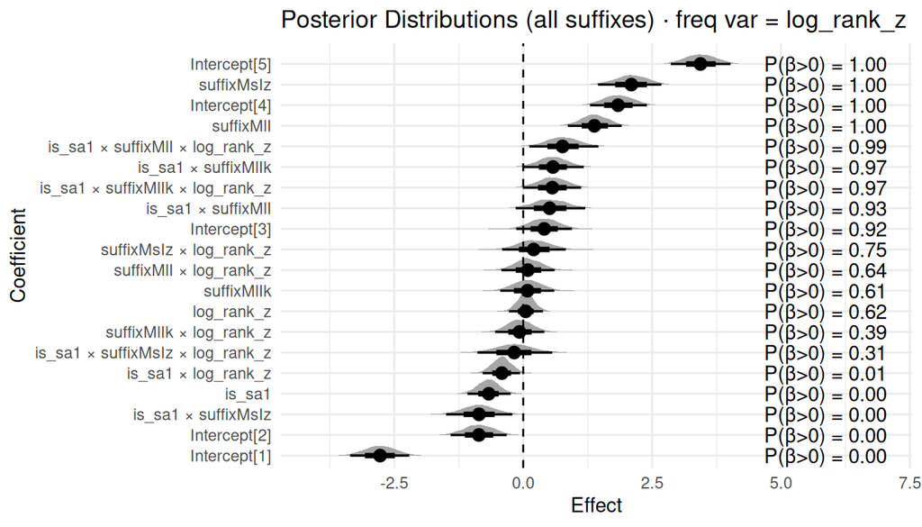

```r
priors_generic <- c(
  prior(normal(0, 0.5), class = "b"),
  prior(normal(0, 5),   class = "Intercept"),
  prior(exponential(1), class = "sd", group = "subject"),
  prior(exponential(1), class = "sd", group = "itemNum"),
  prior(lkj(2),         class = "cor")
)

res <- run_model_all_suffixes(
  data = exp_joined,
  prior = priors_generic,
  freq_var = "log_rank_z",
  chains = 1, iter = 4000, cores = 16,
  adapt_delta = 0.95, max_treedepth = 15,
  threads_per_chain = 2
)
res$plot
```

```r
# head(res$summary)
# res$fixef
```

Model A: is_sa × log_rank_z (rank = rarity)

Key result: the interaction is negative. As pairs become frequent (low rank), the suspended affixation effect is amplified.

Interpretation: suspended affixation (SA) sensitivity tracks usage-based accessibility: more frequent conjunct pairs make the SA-related contrast larger.

### 2.1.1 Conditional Δ(is_sa) within each suffix at mean freq (0)

```r
delta_sa <- suffix_is_sa_contrasts(res$model, exp_joined, freq_var = "log_rank_z", freq_at = 0)
delta_sa$summary
```

```
         suffix         avg p_gt_0  ci_95_low ci_95_high
2.5%...1    -cI -0.67088312 0.0005 -1.0820275 -0.2451953
2.5%...2    -lI -0.15331641 0.3015 -0.7324509  0.4212129
2.5%...3   -lIk -0.09836232 0.3205 -0.5604891  0.3366705
2.5%...4   -sIz -1.52931096 0.0000 -2.0573295 -1.0197578
```

### 2.1.2 Effect of frequency within each suffix, holding is_sa = 1 (suspended)

```r
freq_effects <- freq_effect_by_suffix(
  fit = res$model,
  data = exp_joined,
  freq_var = "log_rank_z",
  low = -1, high = 1, is_sa_level = 1
)

freq_effects$summary
```

```
         suffix        avg p_gt_0  ci_95_low  ci_95_high
2.5%...1    -cI -0.7423387 0.0170 -1.4174035 -0.06276452
2.5%...2    -lI  0.9909461 0.9625 -0.1407234  2.12918045
2.5%...3   -lIk  0.2480706 0.6765 -0.7476208  1.34499981
2.5%...4   -sIz -0.6805115 0.1460 -1.9447855  0.64056663
```

### 2.1.3 Effect of frequency within each suffix, holding is_sa = 0 (not suspended)

```r
freq_effects <- freq_effect_by_suffix(
  fit = res$model,
  data = exp_joined,
  freq_var = "log_rank_z",
  low = -1, high = 1, is_sa_level = 0
)

freq_effects$summary
```

```
         suffix         avg p_gt_0  ci_95_low ci_95_high
2.5%...1    -cI  0.09574785 0.6155 -0.5549809  0.7629232
2.5%...2    -lI  0.28779093 0.7240 -0.6670936  1.2494934
2.5%...3   -lIk -0.03713492 0.4565 -0.9684560  0.9264796
2.5%...4   -sIz  0.51467009 0.8085 -0.6398636  1.7505062
```

### 2.1.4 Itemwise

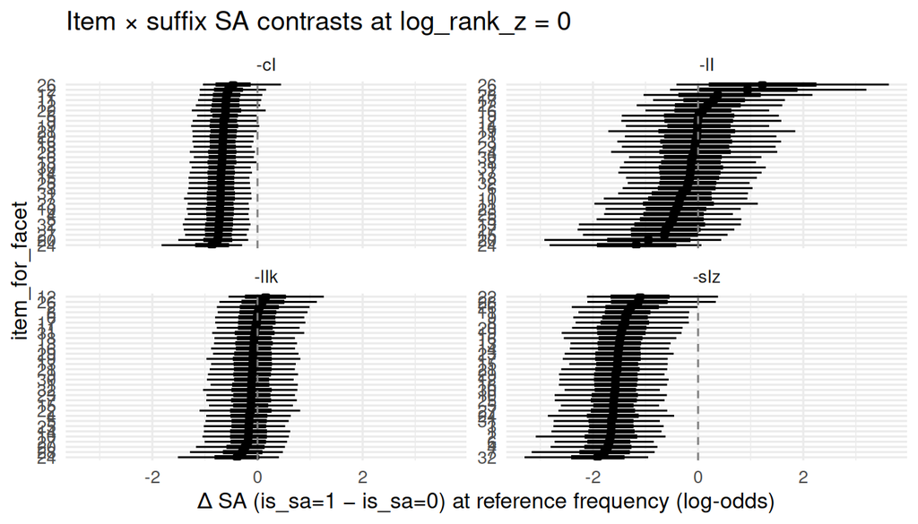

```r
outA <- item_suffix_sa_contrasts(res, freq_var = "log_rank_z",   freq_at = 0)

outA$plot
```

## 2.2 Second plot: fixed-effect posteriors (Model B, `logCoord_z`)

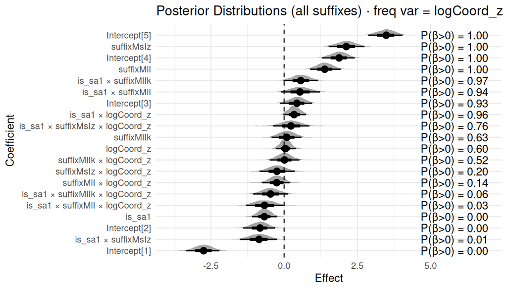

```r
res_log_coord_z <- run_model_all_suffixes(
  data = exp_joined,
  prior = priors_generic,
  freq_var = "logCoord_z",
  chains = 1, iter = 4000, cores = 16,
  adapt_delta = 0.95, max_treedepth = 15,
  threads_per_chain = 2
)

res_log_coord_z$plot
```

```r
# head(res$summary)
# res_log_coord_z$fixef
```

Model B: is_sa × logCoord_z (raw token frequency)

Key result: the interaction is positive. With raw frequency on the log scale (and z-scored), higher logCoord_z means amplified suspended affixation effect.

Convergence with Model A: This mirrors Model A’s finding but with the direct frequency variable: frequent pairs amplify the SA contrast. The opposite signs across Models A and B are mathematically consistent because rank and Coord encode inverse notions of commonness.

Interpretation: the effect is driven by token frequency rather than semantic relatedness per se (especially given the next model).

### 2.2.1 Conditional Δ(is_sa) within each suffix at mean freq (0)

```r
delta_sa <- suffix_is_sa_contrasts(res_log_coord_z$model, exp_joined, freq_var = "logCoord_z", freq_at = 0)
delta_sa$summary
```

```
         suffix        avg p_gt_0  ci_95_low ci_95_high
2.5%...1    -cI -0.6718068 0.0010 -1.0938606 -0.2317369
2.5%...2    -lI -0.1253111 0.3335 -0.7055051  0.4391530
2.5%...3   -lIk -0.1039235 0.3275 -0.5534677  0.3466231
2.5%...4   -sIz -1.5355566 0.0000 -2.0558638 -1.0120883
```

### 2.2.2 Effect of frequency within each suffix, holding is_sa = 1 (suspended)

```r
freq_effects <- freq_effect_by_suffix(
  fit = res_log_coord_z$model,
  data = exp_joined,
  freq_var = "logCoord_z",
  low = -1, high = 1, is_sa_level = 1
)

freq_effects$summary
```

```
         suffix        avg p_gt_0   ci_95_low ci_95_high
2.5%...1    -cI  0.7922182 0.9850  0.06477505 1.51192283
2.5%...2    -lI -1.0628773 0.0295 -2.11381413 0.06066331
2.5%...3   -lIk -0.1050022 0.4115 -1.20973585 0.94746380
2.5%...4   -sIz  0.7754726 0.9230 -0.39502000 1.94511675
```

Patterns for −cI and −lI flip relative to Model A

### 2.2.3 Effect of frequency within each suffix, holding is_sa = 0 (not suspended)

```r
freq_effects <- freq_effect_by_suffix(
  fit = res_log_coord_z$model,
  data = exp_joined,
  freq_var = "logCoord_z",
  low = -1, high = 1, is_sa_level = 0
)

freq_effects$summary
```

```
         suffix         avg p_gt_0  ci_95_low ci_95_high
2.5%...1    -cI  0.09417634 0.6050 -0.5590357  0.7862302
2.5%...2    -lI -0.42547236 0.1620 -1.2662640  0.3873655
2.5%...3   -lIk  0.11760775 0.6000 -0.8668040  1.1297387
2.5%...4   -sIz -0.39084049 0.2325 -1.4565052  0.7381561
```

### 2.2.4 Itemwise

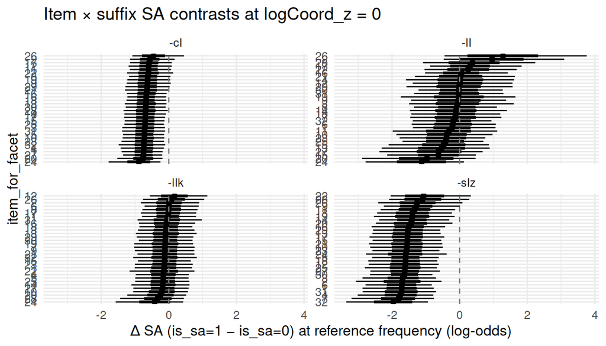

```r
outB <- item_suffix_sa_contrasts(res_log_coord_z,  freq_var = "logCoord_z",   freq_at = 0)

outB$plot
```

When frequency increases, ratings tend to drop for −sIz, the opposite of the suspended case (where high frequency raised ratings). So, in raw frequency space, the suspended and non-suspended curves cross, meaning is_sa × frequency interaction.

## 2.3 Third plot: fixed-effect posteriors (Model C, `log_csumPMI_z`)

```r
exp_joined <- exp_joined %>%
  mutate(log_csumPMI = log1p(csumPMI)) %>%
  mutate(log_csumPMI_z = scale(log1p(csumPMI)))
```

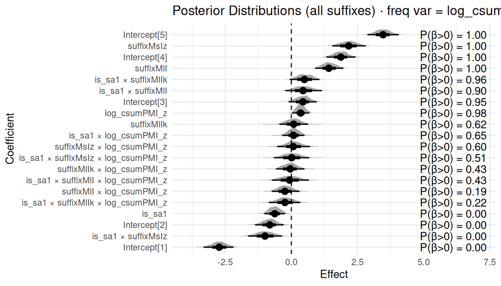

```r
res_log_csumPMI_z <- run_model_all_suffixes(
  data = exp_joined,
  prior = priors_generic,
  freq_var = "log_csumPMI_z",
  chains = 1, iter = 4000, cores = 16,
  adapt_delta = 0.95, max_treedepth = 15,
  threads_per_chain = 2
)

res_log_csumPMI_z$plot
```

```r
# head(res$summary)
# res_log_csumPMI_z$fixef
```

Key result: the interaction is around 0 (no reliable modulation).

Interpretation: Pair-specific association strength (PMI-type, even symmetrized and context-controlled) does not predict the size of the SA contrast once you account for suffix and the full interaction structure. In other words, the semantic ‘tightness’ of a pair is not what drives suspended affixation acceptability.

### 2.3.1 Conditional Δ(is_sa) within each suffix at mean freq (0)

```r
delta_sa <- suffix_is_sa_contrasts(res_log_csumPMI_z$model, exp_joined, freq_var = "log_csumPMI_z", freq_at = 0)
delta_sa$summary
```

```
         suffix        avg p_gt_0  ci_95_low ci_95_high
2.5%...1    -cI -0.6298934 0.0025 -1.0202763 -0.2405604
2.5%...2    -lI -0.1772196 0.2670 -0.7905584  0.4053378
2.5%...3   -lIk -0.1277211 0.2900 -0.5608598  0.3155901
2.5%...4   -sIz -1.6236829 0.0000 -2.1763253 -1.0904902
```

### 2.3.2 Effect of frequency within each suffix, holding is_sa = 1 (suspended)

```r
freq_effects <- freq_effect_by_suffix(
  fit = res_log_csumPMI_z$model,
  data = exp_joined,
  freq_var = "log_csumPMI_z",
  low = -1, high = 1, is_sa_level = 1
)

freq_effects$summary
```

```
         suffix       avg p_gt_0    ci_95_low ci_95_high
2.5%...1    -cI 0.8709933 0.9915  0.192139864   1.529575
2.5%...2    -lI 0.2807153 0.6755 -0.878072605   1.516719
2.5%...3   -lIk 0.2943163 0.7145 -0.722839297   1.340456
2.5%...4   -sIz 1.0376643 0.9725 -0.007975229   2.117223
```

Association-based frequency (csumPMI) shows positive effects for −cI and −sIz but with wider uncertainty elsewhere when it is suspended.

### 2.3.3 Effect of frequency (±1 SD) within each suffix, holding is_sa = 0 (not suspended)

```r
freq_effects <- freq_effect_by_suffix(
  fit = res_log_csumPMI_z$model,
  data = exp_joined,
  freq_var = "log_csumPMI_z",
  low = -1, high = 1, is_sa_level = 0
)

freq_effects$summary
```

```
         suffix       avg p_gt_0   ci_95_low ci_95_high
2.5%...1    -cI 0.7030989 0.9830  0.05510131   1.359565
2.5%...2    -lI 0.2327255 0.6895 -0.66270387   1.152430
2.5%...3   -lIk 0.6066035 0.8900 -0.41749853   1.602383
2.5%...4   -sIz 0.8538959 0.9455 -0.22013920   1.900556
```

Association-based measures again show positive slopes for −cI and −sIz, echoing their general accessibility advantage

### 2.3.4 Itemwise

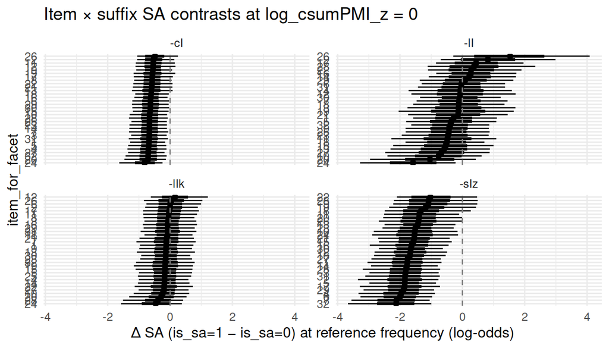

```r
outC <- item_suffix_sa_contrasts(res_log_csumPMI_z,freq_var = "log_csumPMI_z", freq_at = 0)

outC$plot
```

# 3 Overall summary and takeaways

- SA effects strongest for −sIz and −cI, and uncertain for -lI and -lIk. This is seen across all models. Certain suffixes (especially −sIz) are more sensitive to suspended affixation.
- Consistent story from Models A & B: SA effect increases with token frequency of the conjunct pair.
- Model A (rank) -> negative interaction (rarer -> weaker effect).
- Model B (log frequency) -> positive interaction (more frequent -> stronger effect).
- No support for PMI-type predictors: Model C shows that context-controlled association strength does not modulate SA, despite PMI measures correlating strongly with each other.
- Theoretical implication: The frequency-of-form seems to be the operative driver. This aligns with accounts where comprehension of derivational SA relies on availability of well-practiced surface forms rather than pairwise semantic cohesion.